# Summer Internship

Navin Ramanan

6/01/2022

##Setup

1. Map Ensembl ID to Gene Symbol in the counts file

```
## Ensembl site unresponsive, trying uswest mirror
```

2. Write Counts Data with Gene Symbol to CSV
3. Reading and filtering Hippocampus count and metadata files
4. Reading and filtering Cortex count and metadata files
5. Cortex: APP=WT, Age=12, Diet=Control vs Supplemented (~APP + Age + Diet) WT12Control vs WT12Supplemented

```
## Cortex: Running DESeq2 for Diet(Control vs Supplemented) with APP=WT, Age=12:padj < 0.05 and 0.10
```

```
## Cortex: WT12Control vs WT12Supplemented
```

```
## resultsNames:
```

```
##  [1] "Intercept"
##  [2] "group_APP12Supplemented_vs_APP12Control"
##  [3] "group_APP3Control_vs_APP12Control"
##  [4] "group_APP3Supplemented_vs_APP12Control"
##  [5] "group_APP6Control_vs_APP12Control"
##  [6] "group_APP6Supplemented_vs_APP12Control"
##  [7] "group_APP9Control_vs_APP12Control"
##  [8] "group_APP9Supplemented_vs_APP12Control"
##  [9] "group_WT12Control_vs_APP12Control"
## [10] "group_WT12Supplemented_vs_APP12Control"
## [11] "group_WT3Control_vs_APP12Control"
## [12] "group_WT3Supplemented_vs_APP12Control"
## [13] "group_WT6Control_vs_APP12Control"
## [14] "group_WT6Supplemented_vs_APP12Control"
## [15] "group_WT9Control_vs_APP12Control"
## [16] "group_WT9Supplemented_vs_APP12Control"
## [1] "group"            "WT12Control"      "WT12Supplemented"
##
## out of 34880 with nonzero total read count
## adjusted p-value < 0.1
## LFC > 0 (up)       : 5, 0.014%
## LFC < 0 (down)     : 1, 0.0029%
## outliers [1]       : 101, 0.29%
## low counts [2]     : 0, 0%
## (mean count < 0)
## [1] see 'cooksCutoff' argument of ?results
## [2] see 'independentFiltering' argument of ?results
```

```
## log2 fold change (MLE): group WT12Control vs WT12Supplemented
## Wald test p-value: group WT12Control vs WT12Supplemented
## DataFrame with 10 rows and 6 columns
##                     baseMean log2FoldChange     lfcSE      stat      pvalue
##                    <numeric>      <numeric> <numeric> <numeric>   <numeric>
## ENSMUSG00000105481   1.86137      -17.31539  2.357769  -7.34397 2.07342e-13
## ENSMUSG00000068323  12.40222        4.08072  0.758905   5.37711 7.56915e-08
## ENSMUSG00000039672  13.91125        4.12652  0.774918   5.32510 1.00895e-07
## ENSMUSG00000036169  35.08967        2.53086  0.528106   4.79233 1.64856e-06
## ENSMUSG00000001827  29.78217        2.80785  0.616817   4.55215 5.30999e-06
## ENSMUSG00000048108  12.14316        3.60624  0.816857   4.41477 1.01116e-05
## ENSMUSG00000034739  12.17509        3.13406  0.754288   4.15499 3.25299e-05
## ENSMUSG00000026579  57.96381        1.68163  0.408565   4.11594 3.85604e-05
## ENSMUSG00000007888  36.58271        1.38034  0.353986   3.89942 9.64249e-05
## ENSMUSG00000058488 174.32000        1.39223  0.370654   3.75615 1.72545e-04
##                           padj
##                      <numeric>
## ENSMUSG00000105481 7.21114e-09
## ENSMUSG00000068323 1.16967e-03
## ENSMUSG00000039672 1.16967e-03
## ENSMUSG00000036169 1.43338e-02
## ENSMUSG00000001827 3.69352e-02
## ENSMUSG00000048108 5.86121e-02
## ENSMUSG00000034739 1.61622e-01
## ENSMUSG00000026579 1.67637e-01
## ENSMUSG00000007888 3.72618e-01
## ENSMUSG00000058488 6.00095e-01
```

```
## log2 fold change (MLE): group WT12Control vs WT12Supplemented
## Wald test p-value: group WT12Control vs WT12Supplemented
## DataFrame with 34880 rows and 6 columns
##                       baseMean log2FoldChange     lfcSE      stat      pvalue
##                      <numeric>      <numeric> <numeric> <numeric>   <numeric>
## ENSMUSG00000105481     1.86137      -17.31539  2.357769  -7.34397 2.07342e-13
## ENSMUSG00000068323    12.40222        4.08072  0.758905   5.37711 7.56915e-08
## ENSMUSG00000039672    13.91125        4.12652  0.774918   5.32510 1.00895e-07
## ENSMUSG00000036169    35.08967        2.53086  0.528106   4.79233 1.64856e-06
## ENSMUSG00000001827    29.78217        2.80785  0.616817   4.55215 5.30999e-06
## ...                        ...            ...       ...       ...         ...
## ENSMUSG00000109212    0.769426       0.000000  8.245409  0.000000          NA
## ENSMUSG00000054134   40.269651      -0.179806  0.763615 -0.235467          NA
## ENSMUSG00000024028    0.789155       0.000000  8.245409  0.000000          NA
## ENSMUSG00000061808 1664.189531       5.254761  0.828300  6.344035          NA
## ENSMUSG00000037451    1.547250       0.000000  8.245409  0.000000          NA
##                           padj
##                      <numeric>
## ENSMUSG00000105481 7.21114e-09
## ENSMUSG00000068323 1.16967e-03
## ENSMUSG00000039672 1.16967e-03
## ENSMUSG00000036169 1.43338e-02
## ENSMUSG00000001827 3.69352e-02
## ...                        ...
## ENSMUSG00000109212          NA
## ENSMUSG00000054134          NA
## ENSMUSG00000024028          NA
## ENSMUSG00000061808          NA
## ENSMUSG00000037451          NA
```

```
## class: DESeqDataSet
## dim: 34880 96
## metadata(1): version
## assays(4): counts mu H cooks
## rownames(34880): ENSMUSG00000102628 ENSMUSG00000097426 ...
##   ENSMUSG00000095041 ENSMUSG00000095742
## rowData names(78): baseMean baseVar ... deviance maxCooks
## colnames(96): 102 103 ... 95 96
## colData names(6): Sex Diet ... group sizeFactor
```

```
## Cortex DESeq2 result is saved in file: 'Cortex_deseq_results_Diet_WT_12.csv'
```

```
## Cortex DESeq2 normalized counts is saved in file: 'Cortex_deseq_norm_counts_Diet_WT_12.csv'
```

```
## Cortex DESeq2 result with Gene names (mgi_symbols) is saved in file: 'Cortex_deseq_results_with_genename_Diet_WT_12.csv'
```

```
## [1] 34880
```

```
## [1] 5
```

```
## Cortex DESeq2 result after padj (0.05) filtering is saved in file: 'Cortex_deseq_results_Diet_WT_12_padj_05_filtered.csv'
```

```
## Number of DE genes significant at padj < 0.05 for Cortex:WT12Control vs WT12Supplemented: 5
```

```
## Number of DE genes discarded after padj threshold 0.05 filtering for Cortex:WT12Control vs WT12Supplemented: 34875
```

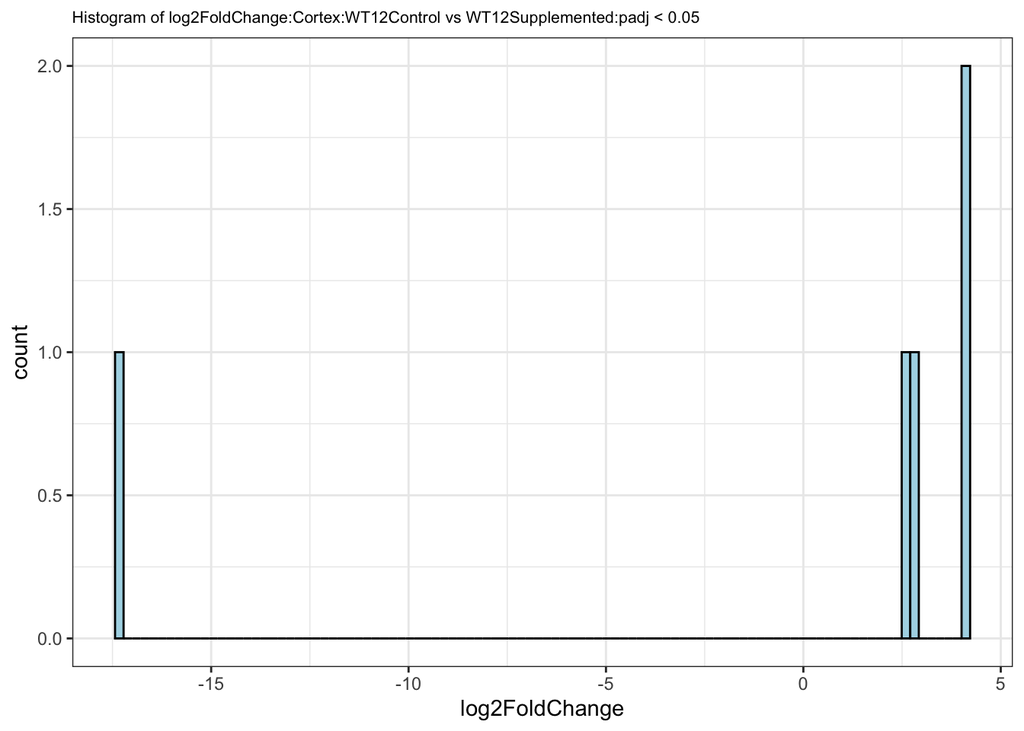

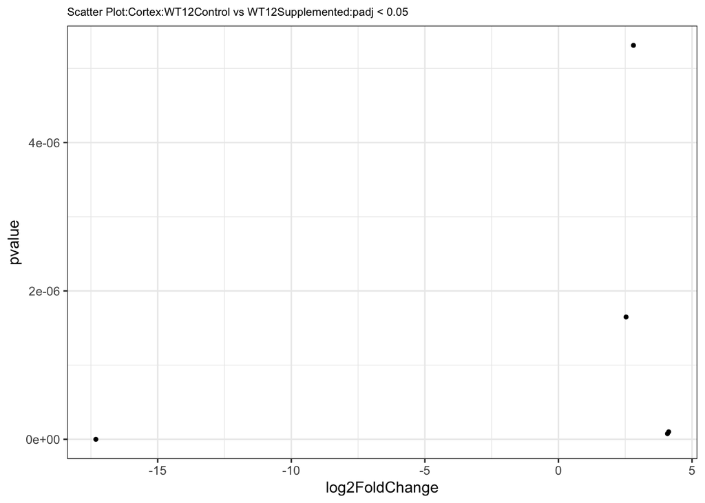

```
## [1] 34880
```

```
## [1] 6
```

```
## Cortex DESeq2 result after padj (0.1) filtering is saved in file: 'Cortex_deseq_results_Diet_WT_12_padj_1_filtered.csv'
```

```
## Number of DE genes significant at padj < 0.1 for Cortex:WT12Control vs WT12Supplemented: 6
```

```
## Number of DE genes discarded after padj threshold 0.1 filtering for Cortex:WT12Control vs WT12Supplemented: 34874
```

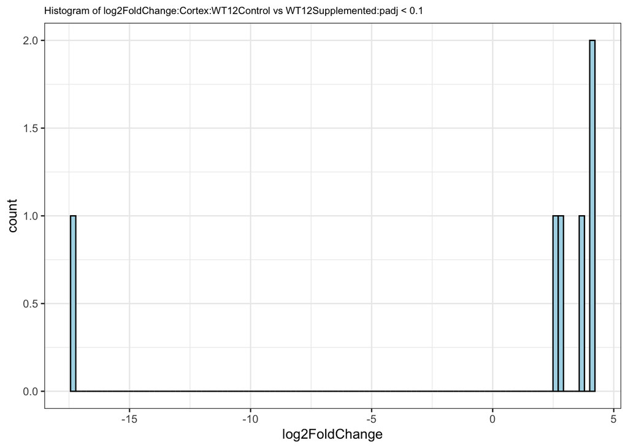

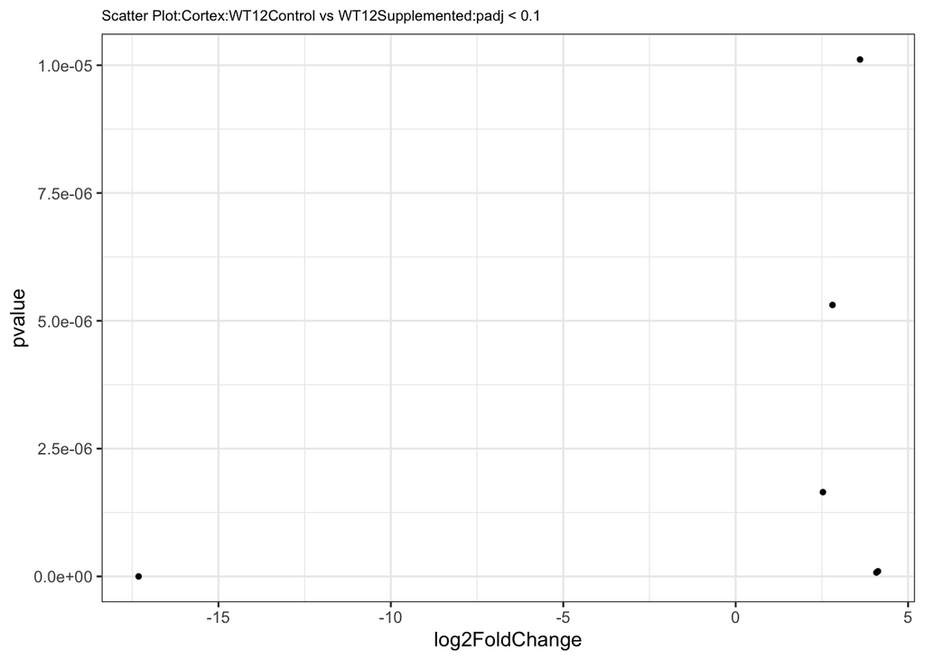

6. Cortex: Enhanced Volcano Plot

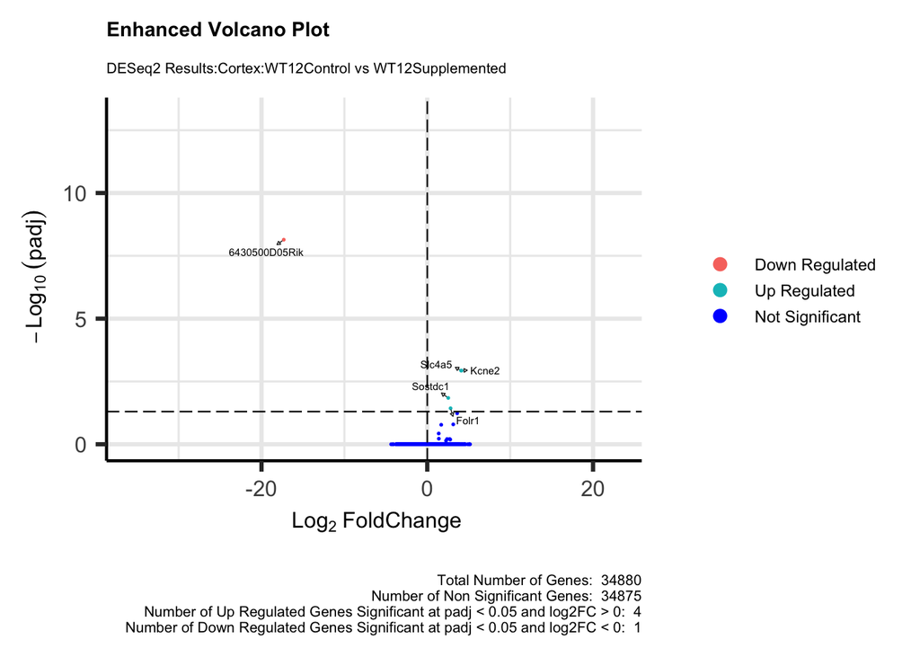

7. Cortex: Heatmap

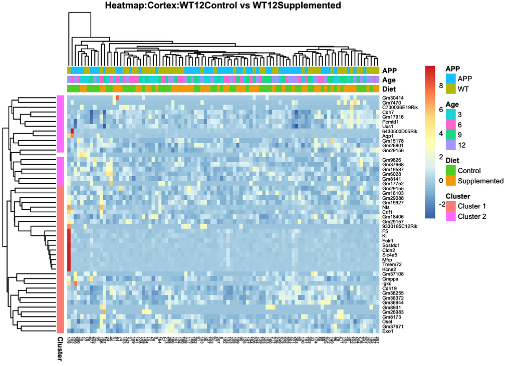

8. Hippocampus: APP=WT, Age=12, Diet=Control vs Supplemented (~APP + Age + Diet) WT12Control vs WT12Supplemented

```
## Hippocampus: Running DESeq2 for Diet(Control vs Supplemented) with APP=WT, Age=12:padj < 0.05 and 0.10
```

```
## Hippocampus: WT12Control vs WT12Supplemented
```

```
## resultsNames:
```

```
##  [1] "Intercept"
##  [2] "group_APP12Supplemented_vs_APP12Control"
##  [3] "group_APP3Control_vs_APP12Control"
##  [4] "group_APP3Supplemented_vs_APP12Control"
##  [5] "group_APP6Control_vs_APP12Control"
##  [6] "group_APP6Supplemented_vs_APP12Control"
##  [7] "group_APP9Control_vs_APP12Control"
##  [8] "group_APP9Supplemented_vs_APP12Control"
##  [9] "group_WT12Control_vs_APP12Control"
## [10] "group_WT12Supplemented_vs_APP12Control"
## [11] "group_WT3Control_vs_APP12Control"
## [12] "group_WT3Supplemented_vs_APP12Control"
## [13] "group_WT6Control_vs_APP12Control"
## [14] "group_WT6Supplemented_vs_APP12Control"
## [15] "group_WT9Control_vs_APP12Control"
## [16] "group_WT9Supplemented_vs_APP12Control"
## [1] "group"            "WT12Control"      "WT12Supplemented"
##
## out of 33271 with nonzero total read count
## adjusted p-value < 0.1
## LFC > 0 (up)       : 1, 0.003%
## LFC < 0 (down)     : 0, 0%
## outliers [1]       : 77, 0.23%
## low counts [2]     : 0, 0%
## (mean count < 0)
## [1] see 'cooksCutoff' argument of ?results
## [2] see 'independentFiltering' argument of ?results
```

```
## log2 fold change (MLE): group WT12Control vs WT12Supplemented
## Wald test p-value: group WT12Control vs WT12Supplemented
## DataFrame with 10 rows and 6 columns
##                     baseMean log2FoldChange     lfcSE      stat      pvalue
##                    <numeric>      <numeric> <numeric> <numeric>   <numeric>
## ENSMUSG00000060791  48.78016       1.207744  0.247376  4.882217 1.04900e-06
## ENSMUSG00000033227   6.90488       4.515713  1.100118  4.104753 4.04747e-05
## ENSMUSG00000029304 863.24558       1.673908  0.414466  4.038707 5.37468e-05
## ENSMUSG00000067149  23.26136       2.318962  0.571836  4.055294 5.00713e-05
## ENSMUSG00000052688  85.83524       1.206432  0.310217  3.888995 1.00660e-04
## ENSMUSG00000006014  86.71581       2.445645  0.623211  3.924266 8.69945e-05
## ENSMUSG00000035946   4.35289       4.346345  1.110270  3.914673 9.05267e-05
## ENSMUSG00000037254 155.64462       2.151673  0.564484  3.811750 1.37987e-04
## ENSMUSG00000001349  32.66260       2.442205  0.670631  3.641655 2.70891e-04
## ENSMUSG00000102628   4.93307       0.108959  0.713710  0.152666 8.78662e-01
##                         padj
##                    <numeric>
## ENSMUSG00000060791 0.0348205
## ENSMUSG00000033227 0.4460174
## ENSMUSG00000029304 0.4460174
## ENSMUSG00000067149 0.4460174
## ENSMUSG00000052688 0.4773304
## ENSMUSG00000006014 0.4773304
## ENSMUSG00000035946 0.4773304
## ENSMUSG00000037254 0.5725408
## ENSMUSG00000001349 0.9991053
## ENSMUSG00000102628 1.0000000
```

```
## log2 fold change (MLE): group WT12Control vs WT12Supplemented
## Wald test p-value: group WT12Control vs WT12Supplemented
## DataFrame with 33271 rows and 6 columns
##                       baseMean log2FoldChange     lfcSE       stat      pvalue
##                      <numeric>      <numeric> <numeric>  <numeric>   <numeric>
## ENSMUSG00000060791    48.78016        1.20774  0.247376    4.88222 1.04900e-06
## ENSMUSG00000033227     6.90488        4.51571  1.100118    4.10475 4.04747e-05
## ENSMUSG00000029304   863.24558        1.67391  0.414466    4.03871 5.37468e-05
## ENSMUSG00000067149    23.26136        2.31896  0.571836    4.05529 5.00713e-05
## ENSMUSG00000052688    85.83524        1.20643  0.310217    3.88900 1.00660e-04
## ...                        ...            ...       ...        ...         ...
## ENSMUSG00000068196   434.29152       1.373345   1.19519  1.1490643          NA
## ENSMUSG00000053375     1.58633      -0.179309   3.17514 -0.0564727          NA
## ENSMUSG00000023122    38.89638       1.736262   2.47189  0.7024031          NA
## ENSMUSG00000023943    18.46229       2.038521   2.60005  0.7840301          NA
## ENSMUSG00000061808 34756.71162       2.169921   1.53464  1.4139606          NA
##                         padj
##                    <numeric>
## ENSMUSG00000060791 0.0348205
## ENSMUSG00000033227 0.4460174
## ENSMUSG00000029304 0.4460174
## ENSMUSG00000067149 0.4460174
## ENSMUSG00000052688 0.4773304
## ...                      ...
## ENSMUSG00000068196        NA
## ENSMUSG00000053375        NA
## ENSMUSG00000023122        NA
## ENSMUSG00000023943        NA
## ENSMUSG00000061808        NA
```

```
## class: DESeqDataSet
## dim: 33271 96
## metadata(1): version
## assays(4): counts mu H cooks
## rownames(33271): ENSMUSG00000102628 ENSMUSG00000086053 ...
##   ENSMUSG00000095041 ENSMUSG00000095742
## rowData names(78): baseMean baseVar ... deviance maxCooks
## colnames(96): 102 103 ... 95 96
## colData names(6): Sex Diet ... group sizeFactor
```

```
## Hippocampus DESeq2 result is saved in file: 'Hippocampus_deseq_results_Diet_WT_12.csv'
```

```
## Hippocampus DESeq2 normalized counts is saved in file: 'Hippocampus_deseq_norm_counts_Diet_WT_12.csv'
```

```
## Hippocampus DESeq2 result with Gene names (mgi_symbols) is saved in file: 'Hippocampus_deseq_results_with_genename_Diet_WT_12.csv'
```

```
## Hippocampus DESeq2 result after padj (0.05) filtering is saved in file: 'Hippocampus_deseq_results_Diet_WT_12_padj_05_filtered.csv'
```

```
## Number of DE genes significant at padj < 0.05 for Hippocampus:WT12Control vs WT12Supplemented: 1
```

```
## Number of DE genes discarded after padj threshold < 0.05 filtering for Hippocampus:WT12Control vs WT12Supplemented: 33270
```

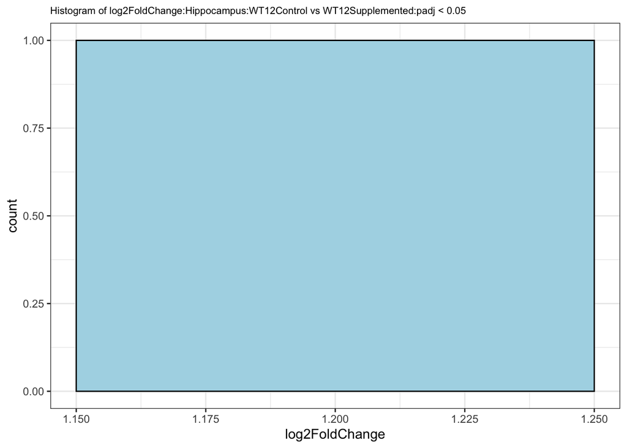

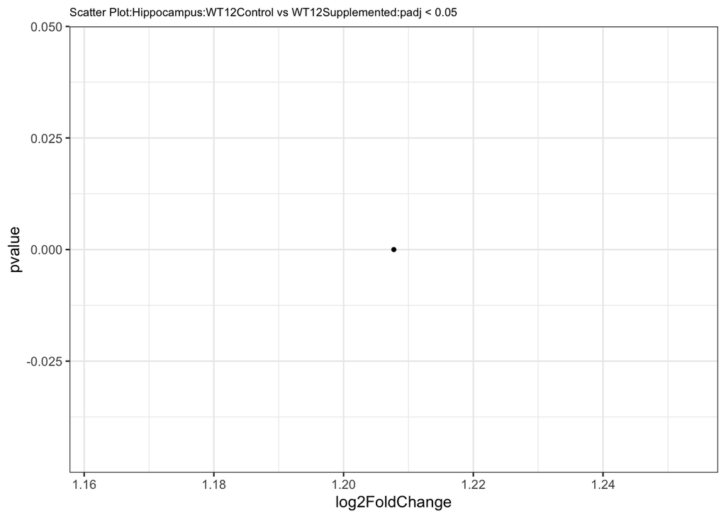

```
## Hippocampus DESeq2 result after padj (0.1) filtering is saved in file: 'Hippocampus_deseq_results_Diet_WT_12_padj_1_filtered.csv'
```

```
## Number of DE genes significant at padj < 0.1 for Hippocampus:WT12Control vs WT12Supplemented: 1
```

```
## Number of DE genes discarded after padj threshold < 0.1 filtering for Hippocampus:WT12Control vs WT12Supplemented: 33270
```

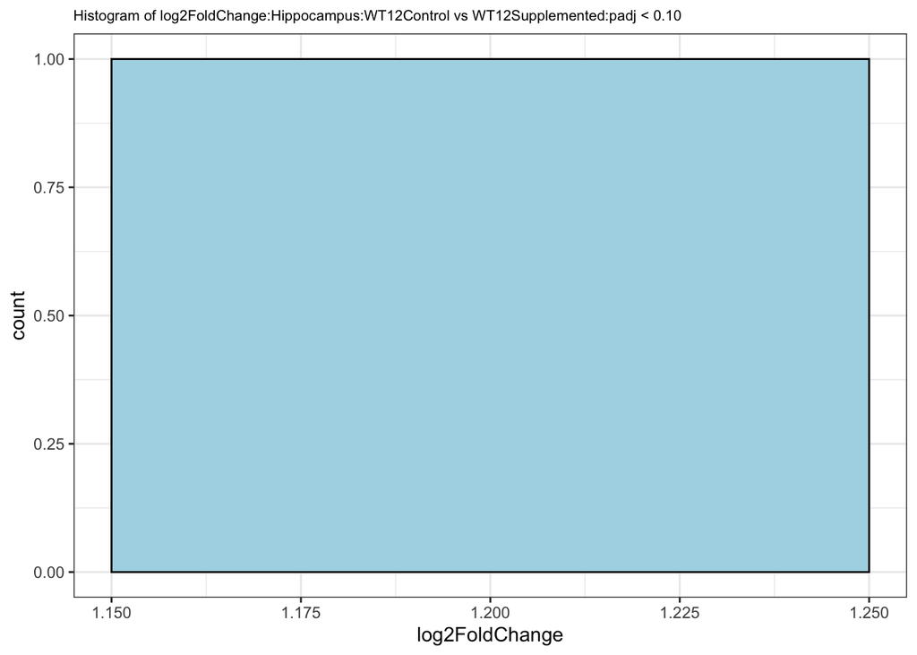

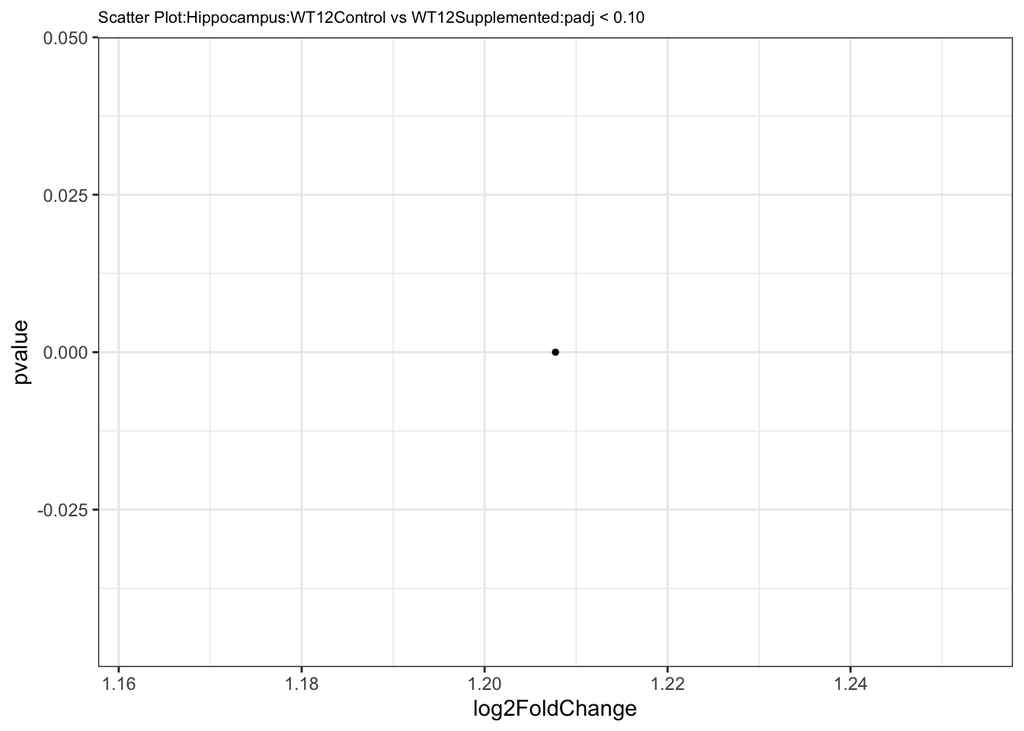

9. Hippocampus: Enhanced Volcano Plot

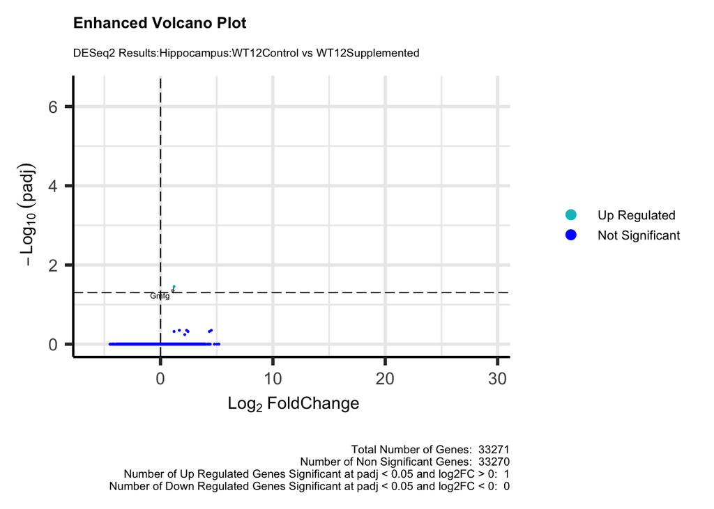

10. Hippocampus: Heatmap

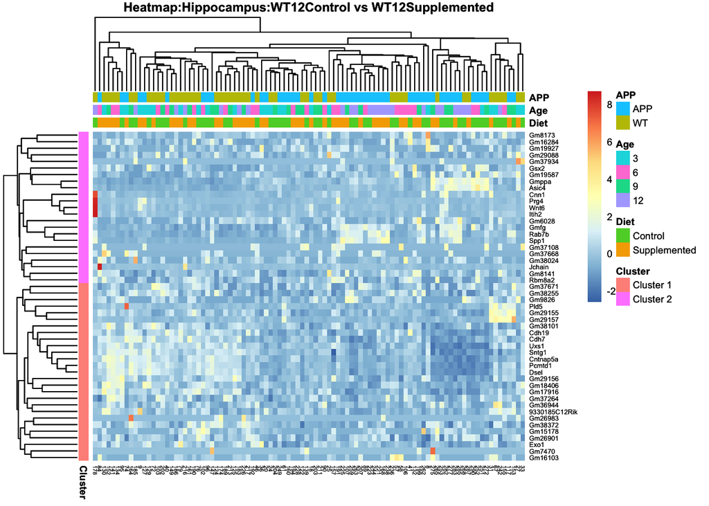

11. GSEA:Running fgsea

Perform a GSEA using a ranked list log2FoldChange values for all genes discovered in the DESeq2 results against the M2 Canonical Pathways gene set collection. Convert gene identifiers in the results to the appropriate matching format found in the M2 gene sets. fgsea expects a named vector of gene level statistics and the gene sets in the form of a named list.

Using “m2.cp.wikipathways.v0.3.symbols.gmt” which is the Canonical Pathways gene sets derived from the WikiPathways pathway database (WikiPathways subset of CP)

```
## # A tibble: 34,880 × 8
##    genes              volc_plot_s…¹ log2F…²    padj baseM…³ lfcSE  stat   pvalue
##    <chr>              <chr>           <dbl>   <dbl>   <dbl> <dbl> <dbl>    <dbl>
##  1 ENSMUSG00000105481 DOWN           -17.3  7.21e-9    1.86 2.36  -7.34 2.07e-13
##  2 ENSMUSG00000068323 UP               4.08 1.17e-3   12.4  0.759  5.38 7.57e- 8
##  3 ENSMUSG00000039672 UP               4.13 1.17e-3   13.9  0.775  5.33 1.01e- 7
##  4 ENSMUSG00000036169 UP               2.53 1.43e-2   35.1  0.528  4.79 1.65e- 6
##  5 ENSMUSG00000001827 UP               2.81 3.69e-2   29.8  0.617  4.55 5.31e- 6
##  6 ENSMUSG00000048108 NS               3.61 5.86e-2   12.1  0.817  4.41 1.01e- 5
##  7 ENSMUSG00000034739 NS               3.13 1.62e-1   12.2  0.754  4.15 3.25e- 5
##  8 ENSMUSG00000026579 NS               1.68 1.68e-1   58.0  0.409  4.12 3.86e- 5
##  9 ENSMUSG00000007888 NS               1.38 3.73e-1   36.6  0.354  3.90 9.64e- 5
## 10 ENSMUSG00000058488 NS               1.39 6.00e-1  174.   0.371  3.76 1.73e- 4
## # … with 34,870 more rows, and abbreviated variable names ¹volc_plot_status,
## #   ²log2FoldChange, ³baseMean
## # ℹ Use `print(n = ...)` to see more rows
```

```
## # A tibble: 190 × 8
##    pathway                        pval  padj log2err     ES    NES  size leadi…¹
##    <chr>                         <dbl> <dbl>   <dbl>  <dbl>  <dbl> <int> <list>
##  1 WP_GPCRS_ODORANT             0.0488     1  0.322  -0.445 -1.30    114 <chr>
##  2 WP_BMP_SIGNALING_PATHWAY_IN… 0.144      1  0.172  -0.584 -1.28     20 <chr>
##  3 WP_NODLIKE_RECEPTOR_NLR_SIG… 0.196      1  0.144  -0.706 -1.27      9 <chr>
##  4 WP_BDNF_PATHWAY              0.152      1  0.164  -0.617 -1.26     15 <chr>
##  5 WP_GPCRS_OTHER               0.118      1  0.202  -0.438 -1.22     84 <chr>
##  6 WP_IRINOTECAN_PATHWAY        0.306      1  0.110  -0.725 -1.18      6 <chr>
##  7 WP_GPCRS_CLASS_A_RHODOPSINL… 0.266      1  0.139  -0.353 -1.06    172 <chr>
##  8 WP_GLYCOLYSIS_AND_GLUCONEOG… 0.319      1  0.118  -0.416 -1.06     49 <chr>
##  9 WP_ESTROGEN_METABOLISM       0.517      1  0.0804 -0.497 -0.955    12 <chr>
## 10 WP_HEME_BIOSYNTHESIS         0.503      1  0.0822 -0.531 -0.952     9 <chr>
## # … with 180 more rows, and abbreviated variable name ¹leadingEdge
## # ℹ Use `print(n = ...)` to see more rows
```

```
## Cortex NES ordered fgsea results saved in file: 'Cortex_NES_ordered_fgsea_results_Diet_WT_12_FC0.csv'
```

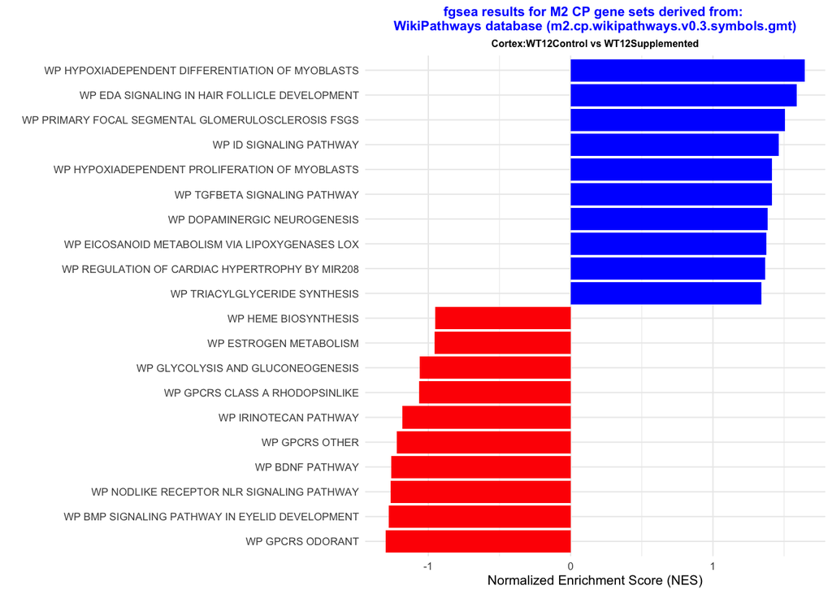

```
## # A tibble: 33,271 × 8
##    genes              volc_plot_sta…¹ log2F…²   padj baseM…³ lfcSE  stat  pvalue
##    <chr>              <chr>             <dbl>  <dbl>   <dbl> <dbl> <dbl>   <dbl>
##  1 ENSMUSG00000060791 UP                1.21  0.0348   48.8  0.247 4.88  1.05e-6
##  2 ENSMUSG00000033227 NS                4.52  0.446     6.90 1.10  4.10  4.05e-5
##  3 ENSMUSG00000029304 NS                1.67  0.446   863.   0.414 4.04  5.37e-5
##  4 ENSMUSG00000067149 NS                2.32  0.446    23.3  0.572 4.06  5.01e-5
##  5 ENSMUSG00000052688 NS                1.21  0.477    85.8  0.310 3.89  1.01e-4
##  6 ENSMUSG00000006014 NS                2.45  0.477    86.7  0.623 3.92  8.70e-5
##  7 ENSMUSG00000035946 NS                4.35  0.477     4.35 1.11  3.91  9.05e-5
##  8 ENSMUSG00000037254 NS                2.15  0.573   156.   0.564 3.81  1.38e-4
##  9 ENSMUSG00000001349 NS                2.44  0.999    32.7  0.671 3.64  2.71e-4
## 10 ENSMUSG00000102628 NS                0.109 1         4.93 0.714 0.153 8.79e-1
## # … with 33,261 more rows, and abbreviated variable names ¹volc_plot_status,
## #   ²log2FoldChange, ³baseMean
## # ℹ Use `print(n = ...)` to see more rows
```

```
## # A tibble: 190 × 8
##    pathway                        pval  padj log2err     ES    NES  size leadi…¹
##    <chr>                         <dbl> <dbl>   <dbl>  <dbl>  <dbl> <int> <list>
##  1 WP_STEROID_BIOSYNTHESIS      0.0966 0.966  0.204  -0.739 -1.40      9 <chr>
##  2 WP_HYPOXIADEPENDENT_SELFREN… 0.150  1      0.161  -0.616 -1.28     13 <chr>
##  3 WP_GLUCURONIDATION           0.310  1      0.107  -0.610 -1.16      9 <chr>
##  4 WP_GENE_REGULATORY_NETWORK_… 0.323  1      0.105  -0.582 -1.12     10 <chr>
##  5 WP_MIR127_IN_MESENDODERM_DI… 0.390  1      0.0926 -0.582 -1.07      8 <chr>
##  6 WP_SPLICING_FACTOR_NOVA_REG… 0.343  1      0.104  -0.395 -1.05     41 <chr>
##  7 WP_ERBB_SIGNALING_PATHWAY    0.377  1      0.0989 -0.388 -1.05     46 <chr>
##  8 WP_OSTEOBLAST_SIGNALING      0.475  1      0.0822 -0.521 -0.986     9 <chr>
##  9 WP_PEROXIREDOXIN_2_INDUCED_… 0.535  1      0.0751 -0.561 -0.959     6 <chr>
## 10 WP_FATTY_ACID_OMEGAOXIDATION 0.610  1      0.0685 -0.528 -0.902     6 <chr>
## # … with 180 more rows, and abbreviated variable name ¹leadingEdge
## # ℹ Use `print(n = ...)` to see more rows
```

```
## Hippocampus NES ordered fgsea results saved in file: 'Hippocampus_NES_ordered_fgsea_results_Diet_WT_12_FC0.csv'
```

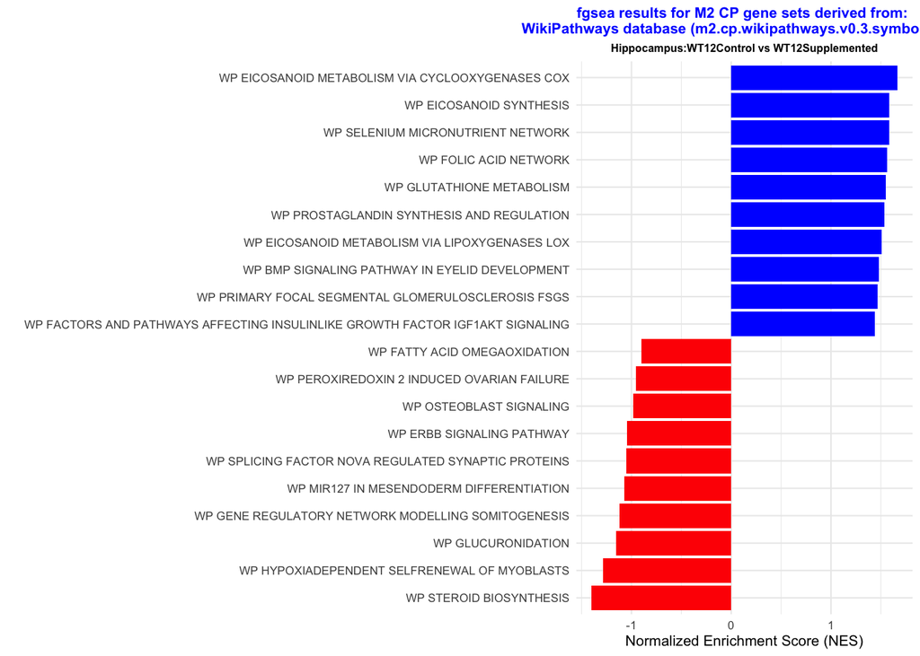